# Step by step of implementing niche-neutral framework using mixed models

Sara Mortara & Paulo Prado

07 de maio de 2018

### Presentation

The general idea of our framework is to translate niche and neutral dynamics on community assembly into fixed and random effects of generalized mixed models. Within our framework one can simultaneosly test the importance of niche solely, neutrality solely and combinations of niche and neutral effects on community structure (abundance or occurrence).

We use the model selection approach to test multiple hypothesis and we use conditional and marginal $R^{2}$ values to quantify the relative importance of niche and neutrality on community structure.

Main crtiticism of our framework rely on: (1) Are fixed and random effects actually capturing niche and neutral dynamics? (2) Are random effects only capturing neutral dynamics or overdipersion in data and uninformed species traits are inflating random effects?

In order to show how we implemented our framework and how model components are translated into niche and neutral dynamics we perform simulations below. We do not intend to scan all parameter space of type of communities and traits, neither make a comprehensive investigation of sampling effetcs. Our goal with this tutorial is to adress main criticisms of our framework and show how promising our framework is to quantify the relative importance of niche and neutral dynamics.

## A test of our modelling framework

Here, we present a working example of our modelling framwork. We use simulated communities based on niche and neutral dynamics in order to show how fixed and random effects capture different ecological processes. Also, we use strong and week traits in order to show how fixed and random effects capture neutral dynamics when traits are strong. Therefore, we simulate stochastic and deterministic metacommunities and use strong or weak traits in model selection.

We simulate metacommunities with the same data structure as our abundance data of ferns in three mountain chains in southern Brazil. Then, we make poisson and negative binomial samples of communities and use samples from the metacommunities in our model selection framework.

In order to acess main criticisms of our framework, we look into four scenarios:

- Deterministic community with right traits from Poisson sample
- Deterministic community with wrong traits from Poisson sample
- Stochastic community with right traits from Poisson sample
- Stochastic community with right traits from Negative Binomial sample

### 1. Building simulated communities

#### 1.1. Getting data for simulations

```r
library(devtools)
library(MCSim)
library(ade4)
library(vegan)
library(lme4)
library(bbmle)
library(optimx)
library(piecewiseSEM)
library(sads)
library(ggplot2)
library(dplyr)
library(MASS)
library(knitr)

set.seed(42)
```

First, we generate the metacoomunity data. Code used here is adapted from Sokol’s tutorial. We create data from 30 sites across three mountain chains. We simulate abundance values for 20 different species.

For both deterministic and stochastic scenarios, we simulate 10 different metacommunities until timestep 100 and then take mean values from the 100th last timestep.

```r
## Number of sites
Nsites <- 30
## Number of regions
Nregions <- 3
## Number of species
Nspp <- 20

## Sites attributes ##
## Here are the xy-coordinates of sites: 3 regions with 10 sites each
## Distances between regions is an order of amgnitude distance bewteen sites within regions
sites <- expand.grid(x = seq(0,120, length=Nregions), y=seq(1,5, length=Nsites/Nregions))
sites$x <- jitter(sites$x)
sites$y <- jitter(sites$y)
## Each set of 10 points at same x coordinate is labelled as a region
sites$region <- rep(letters[1:Nregions], Nsites/Nregions)
## Enviromental variable: 10 states, that repeat at each site (e.g. altitude)
sites$env <- rep(seq(1,5, length=Nsites/Nregions), each=Nregions)

## Calculate niches for species: optimal values along the enviromental variable
sp.opt <- runif(Nspp, min = 1, max = 5)
```

#### 1.2 Deterministic community

##### 1.2.1 Building the landscape

```r
## Following Sokol's tutorial we arbitrarily chose JM = 1e6
JM <- 1e6

## We set m=0.5 to allow some dispersal limitation. Still a half of the deaths are replaced by locals

simulation_landscape_det <- MCSim::fn.make.landscape(
  site.coords = sites[,1:2],
  Ef = sites$env,
  m = 0.5,
  JM = JM)
## It seems that in R 3.5 it is necessary to convert the dist mat in this object form dataframe to a matrix
simulation_landscape_det$dist.mat <-  as.matrix(simulation_landscape_det$dist.mat)
```

##### 1.2.2 Simulating abundances of deterministic communities

```r
## Initial condition ##
## Initial condition: matrix of sites x spp

## Random values of species abundances
m0b <- matrix(rlnorm(Nspp*Nsites), Nsites, Nspp)
## Splitting species in 3 fractions that are exclusive of each region
R.ind <- sample(letters[1:Nregions], Nspp, replace=TRUE)
for(i in letters[1:Nregions])
    m0b[sites$region=="i",R.ind!="i"] <- 0
## Calculating Relative abundances
m0b <- sweep(m0b, 1, apply(m0b,1,sum), FUN="/")

## Data frames to store simulations
id <- data.frame(site=rep(1:Nsites, Nspp), sites[,3:4], spp=rep(paste("sp",1:Nspp, sep="."), each=Nsites))
## To store simulation results
det.resu <- matrix(NA, nrow=nrow(id), ncol=10)

for(i in 1:10){
    simu.det <- MCSim::fn.metaSIM( # simulation of deterministic community w correctly observed traits
                           landscape = simulation_landscape_det,
                           ##output.dir.path = 'FERN_SIM_RESULTS_det',
                           ##scenario.ID = 'fern_det',
                           ##sim.ID = 'det',
                           trait.Ef = sp.opt,
                           trait.Ef.sd = 0.5,
                           J.t0 = m0b,
                           ##gamma.abund = gama.init/(sum(gama.init)),
                           n.timestep = 100, # increased to 100 time steps; initial conditions seems to persist after t=30
                           W.r = 0,
                           nu = 0,
                           speciation.limit = 0,
                           save.sim = FALSE
                       )
    det <- subset(simu.det$J.long, timestep=="100")[,4]
    det.resu[,i] <- det
}

det <- data.frame(id, count=rowMeans(det.resu))
```

#### 1.3 Stochastic community

##### 1.3.1 Simulating the landscape

```r
simulation_landscape_sto <- MCSim::fn.make.landscape(
  site.coords = sites[,1:2],
  Ef = sites$env,
  m = 0.5, # reducing immigration parameter, allowing limited dispersal
  JM = 1e6)
## It seems that in R 3.5 it is necessary to convert the dist mat in this object form dataframe to a matrix
simulation_landscape_sto$dist.mat <-  as.matrix(simulation_landscape_sto$dist.mat)
```

##### 1.3.2 Simulating abundances of stochastic communities

```r
## A matrix for the results
sto.resu <- matrix(NA, nrow=nrow(id), ncol=10)

for(i in 1:10){
    simu.sto <- MCSim::fn.metaSIM(
                           landscape = simulation_landscape_sto,
                           #output.dir.path = 'FERN_SIM_RESULTS_sto_RT',
                           #scenario.ID = 'fern__sto_RT',
                           #sim.ID = 'sto_RT',
                           trait.Ef = sp.opt,
                           trait.Ef.sd = 1000, # niche deviation changed for neutral dynamics
                           J.t0 = m0b,
                           ##gamma.abund = gama.init/(sum(gama.init)),
                           n.timestep = 100,
                           W.r = 200, # Dispersal Kernel no longer flat
                           nu = 0,
                           speciation.limit = 0,
                           save.sim = FALSE
                       )
    sto <- subset(simu.sto$J.long, timestep=="100")[,4]
    sto.resu[,i] <- sto
}

sto <- data.frame(id, count=rowMeans(sto.resu))
```

#### 1.4 Taking samples from simulated communities

Then, we take poisson and negative binomial samples of different scenarios.

Here, we are sampling 50% of simulated communities following Poisson and negative binomial distributions.

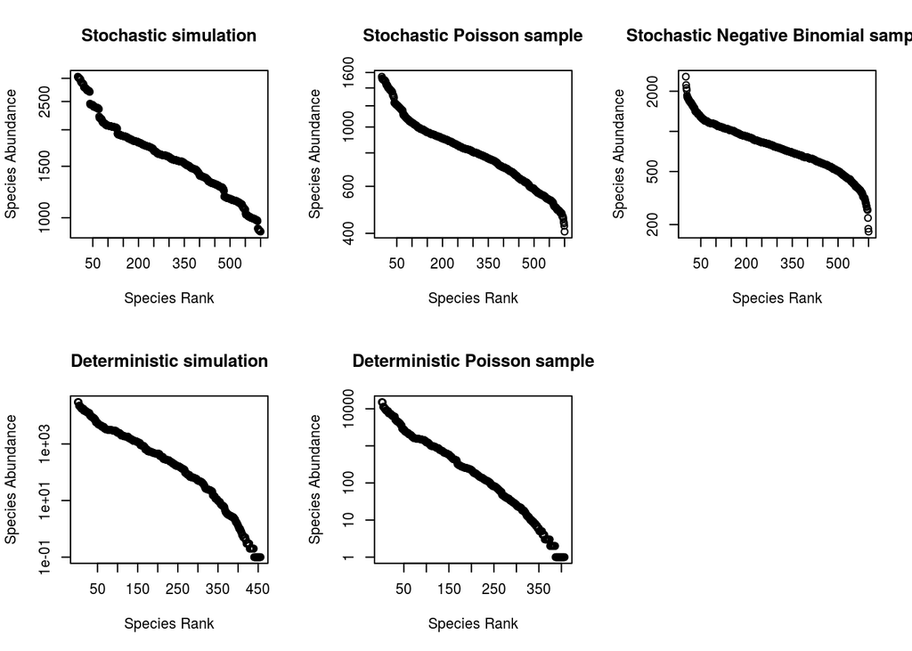

```r
det.pois <- rpois(length(det$count), det$count*0.5)

sto.pois <- rpois(length(sto$count), sto$count*0.5)

sto.nb <- rnbinom(n= length(sto$count),
                  size=gamma.shape(glm(sto$count ~ 1, family=Gamma))$alpha,
                  mu=sto$count*0.5)

## looking into results from simulation and sample
par(mfrow=c(2,3))
plot(rad(sto$count), main="Stochastic simulation")
plot(rad(sto.pois), main="Stochastic Poisson sample")
plot(rad(sto.nb), main="Stochastic Negative Binomial sample")
plot(rad(det$count), main="Deterministic simulation")
plot(rad(det.pois), main="Deterministic Poisson sample")
par(mfrow=c(1,1))
```

### 2. Building hypothesis and models

We aim to simultaneosly test these four main hypotheses:

1. Solely niche dynamics affect species abundance
2. Solely neutral dynamics affect species abundance
3. Niche and neutral dynamics affect species abundance
4. Species abundances vary randomly across regions (null model)

In order to represent each hypothesis, we will build a set of models using glmm with fixed and random effects as below. In general, niche dynamics are represented by fixed effects, whereas neutral dynamics are represented by random effects. Given that species traits are measured at species level, we included species as a random effect on all models, including niche dynamics models. Therefore, this random effect does not represent neutral dynamics, but a random intercept for species abundances.

[output not shown]

### 3. Performing model selection

#### 3.1. Preparing data table for model selection

##### Preparing abundance, trait and environmental data

Here, we combine species abundance data sampled from deterministic and stochastic simulations with traits and environmental data.

```r
# Binding all data togheter
data <- data.frame(site=id[,"site"], spp=id[,"spp"], det=det.pois, sto=sto.pois,
                   sto.nb=sto.nb)

# Now we need species traits, gradient and spacial info

## Traits
## A vector with wrong traits with correlation of less than 0.01 with the true traits
cor.t <- 1
while(cor.t>0.01){
    wrong.t <- runif(length(sp.opt), min(sp.opt), max(sp.opt))
    cor.t <- abs(cor(wrong.t, sp.opt))
}
## Trait data
trait.data <- data.frame(spp=unique(id$spp), trait= scale(sp.opt),
                    trait.wr=scale(wrong.t)) # creating vector w/ wrong traits
## Gradient
env.data <- data.frame(site=unique(id$site), grad=scale(sites$env), region=sites$region)

## Preparing data table for model selection
all.data <- merge(data, env.data, by=c("site"))
all.data <- merge(all.data, trait.data, by=c("spp"))
```

Abundances curves of species along the environmental gradient are as expected:

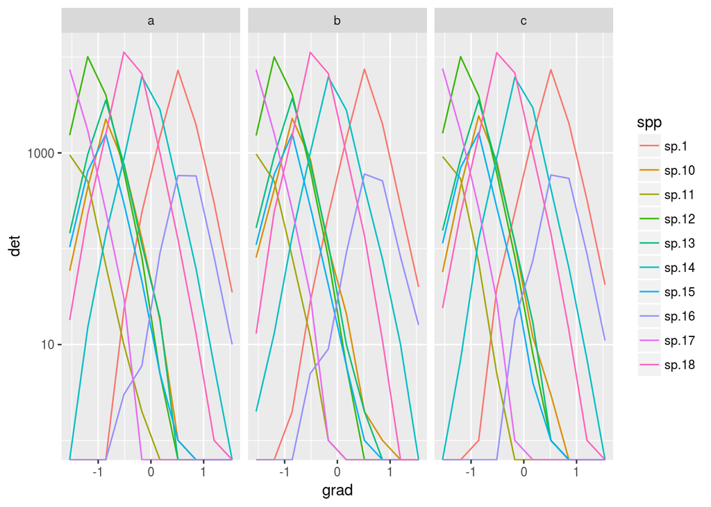

```r
## A sample of species, a panel for each region
## Niche
all.data %>%
    filter(as.integer(spp)<11) %>%
    ggplot(aes(grad, det)) + geom_line(aes(colour=spp)) +
    scale_y_log10()  +
    facet_wrap(~region)
```

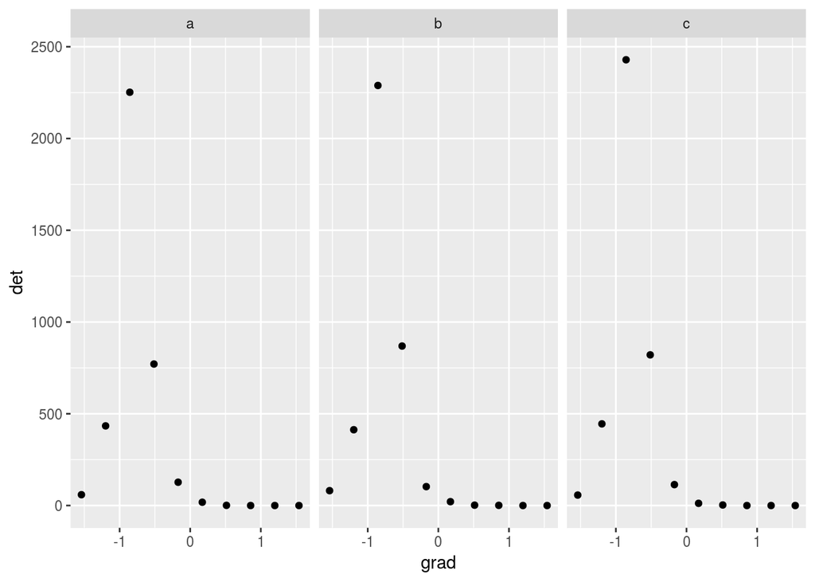

```r
all.data %>%
    filter(spp=="sp.10")%>%
    ggplot(aes(grad, det)) + geom_point() + facet_wrap(~region)
```

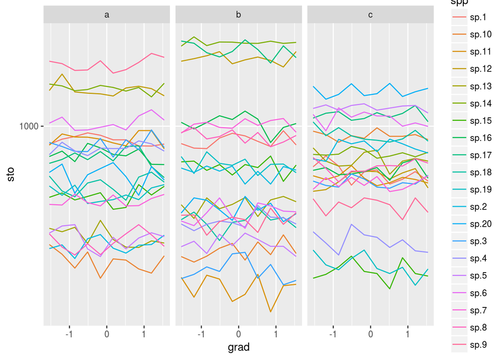

```r
## Neutral
all.data %>%
#    filter(as.integer(spp)<21) %>%
    ggplot(aes(grad, sto)) + geom_line(aes(colour=spp)) +
    scale_y_log10() +
    facet_wrap(~region)
```

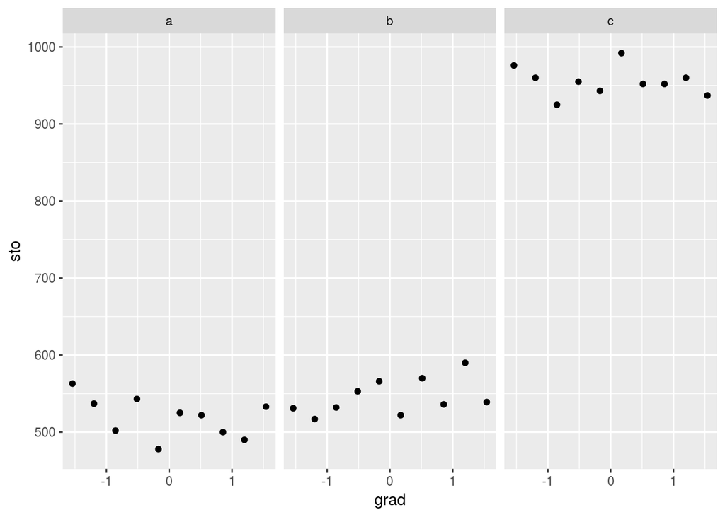

```r
all.data %>%
    filter(spp=="sp.10")%>%
    ggplot(aes(grad, sto)) + geom_point() + facet_wrap(~region)
```

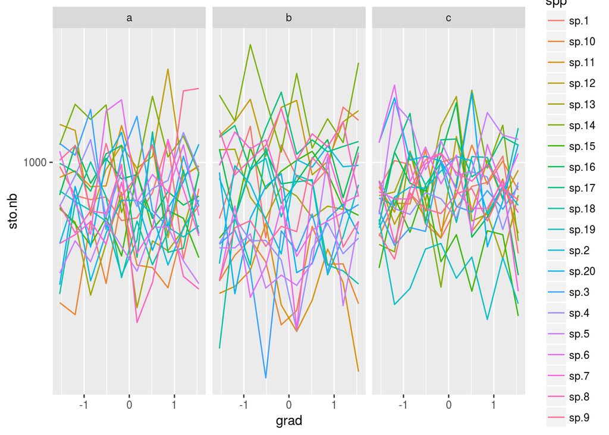

```r
## Neutral from Negative Binomial sample
all.data %>%
#    filter(as.integer(spp)<21) %>%
    ggplot(aes(grad, sto.nb)) + geom_line(aes(colour=spp)) +
    scale_y_log10() +
    facet_wrap(~region)
```

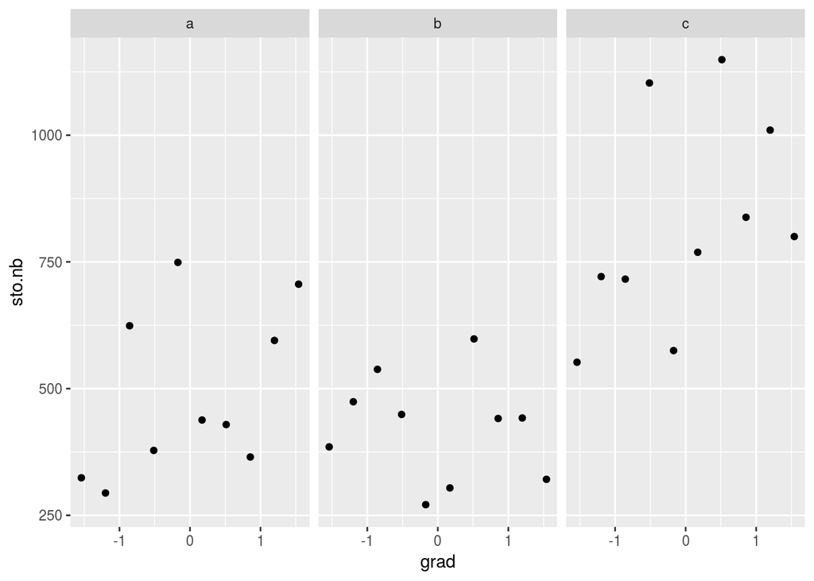

```r
all.data %>%
    filter(spp=="sp.10")%>%
    ggplot(aes(grad, sto.nb)) + geom_point() + facet_wrap(~region)
```

#### 3.2 Performing model selection

First, we create simple functions to perform model selection. Although the logic is generic, functions below are specific to run this example. We create a function for each of our hypothesis.

```r
## 1. Hypothesis of solely niche dynamics
# Niche dynamics models in which abundances are a function of species ecological strategies (traits) or ecological strategies interacting with the environmental gradient (tradeoff model).
m.niche <- function(ab, spp, trait, grad, family, ...){
      es <- glmer(ab ~ trait + (1|spp), family=family,
               control=glmerControl(optimizer="bobyqa", optCtrl=list(maxfun=2e5)))
      es.tradeoff <- glmer(ab ~ trait + I(grad^2) + trait:grad + (1|spp),
                         family=family,
                    control=glmerControl(optimizer="bobyqa",optCtrl=list(maxfun=2e5)))
      return(list(es=es, es.tradeoff=es.tradeoff))
}

## 2. Hypothesis of solely neutral dynamics
# Neutral model in which variation in species abundances are restricted to sites, representing limited dispersal.
m.neu <- function(ab, spp, region, family, ...){
    drift <- glmer(ab ~ 1 + (1|region:spp) + (1|spp), family=family)
    return(drift)
}

## 3. Hypothesis of niche and neutral dynamics
# Models in which niche and neutral dynamics models are combined = niche dynamic models + random term for limited dispersal
m.nineu <- function(ab, trait, grad, spp, region, family, ...){
    es.drift <- glmer(ab ~ trait + (1|region:spp) + (1|spp), family=family,
                      nAGQ=1, control=glmerControl(optimizer="bobyqa",
                                              optCtrl=list(maxfun=500000)))
    es.tradeoff.drift <- glmer(ab ~ trait + I(grad^2) + trait:grad + (1|region:spp) + (1|spp), family=family)
    return(list(es.drift=es.drift, es.tradeoff.drift=es.tradeoff.drift))
}

## 4. Null hypothesis
# Null model in which species and sites are independent random intercepts
m.null <- function(ab, region, spp, family, ...){
      null <- glmer(ab ~ 1 + (1|region) + (1|spp), family=family)
      return(null)
}
```

Now, we will apply all the models to different sets of data.

##### Deterministic community w/ right traits, from poisson sample

```r
# Solely niche dynamics
niche.det.rt <- m.niche(ab=all.data$det,
                        spp=all.data$spp,
                        trait=all.data$trait,
                        grad=all.data$grad, family = "poisson")
# Solely neutral dynamics
neu.det <- m.neu(ab=all.data$det,
                      spp=all.data$spp,
                      region=all.data$region, "poisson")
# Niche and neutral dynamics
nineu.det.rt <- m.nineu(ab=all.data$det,
                        spp=all.data$spp,
                        region=all.data$region,
                        trait=all.data$trait,
                        grad=all.data$grad, "poisson")
# Null hypothesis
null.det <- m.null(ab=all.data$det,
                      spp=all.data$spp,
                      region=all.data$region, "poisson")
# BIC for each model
mod.det.rt.BIC <- BIC(null.det, neu.det,
                   niche.det.rt[[1]], niche.det.rt[[2]],
                   nineu.det.rt[[1]], nineu.det.rt[[2]])
mod.det.rt.BIC <- mod.det.rt.BIC[order(mod.det.rt.BIC[,2]),]
mod.det.rt.BIC
```

```
##                   df       BIC
## niche.det.rt[[2]]  5  242910.0
## nineu.det.rt[[2]]  6  242914.5
## neu.det            3 1324263.3
## niche.det.rt[[1]]  3 1324263.9
## null.det           3 1324265.3
## nineu.det.rt[[1]]  4 1324268.3
```

```r
# R2 for the best model explaining data
sem.model.fits(niche.det.rt[[2]])
```

```
##      Class  Family Link   n  Marginal Conditional
## 1 glmerMod poisson  log 600 0.8914293   0.9999845
```

##### Deterministic community w/ wrong traits, from poisson sample

```r
# Solely niche dynamics
niche.det.wt <- m.niche(ab=all.data$det,
                        spp=all.data$spp,
                        trait=all.data$trait.wr,
                        grad=all.data$grad, family="poisson")
# Niche and neutral dynamics
nineu.det.wt <- m.nineu(ab=all.data$det,
                        spp=all.data$spp,
                        region=all.data$region,
                        trait=all.data$trait.wr,
                        grad=all.data$grad, family="poisson")
# BIC for each model
mod.det.wt.BIC <- BIC(null.det, neu.det,
                   niche.det.wt[[1]], niche.det.wt[[2]],
                   nineu.det.wt[[1]], nineu.det.wt[[2]])
mod.det.wt.BIC <- mod.det.wt.BIC[order(mod.det.wt.BIC[,2]),]
mod.det.wt.BIC
```

```
##                   df     BIC
## niche.det.wt[[2]]  5 1253680
## nineu.det.wt[[2]]  6 1253684
## neu.det            3 1324263
## niche.det.wt[[1]]  3 1324265
## null.det           3 1324265
## nineu.det.wt[[1]]  4 1324269
```

```r
# R2 for the best model explaining data
sem.model.fits(niche.det.wt[[2]])
```

```
##      Class  Family Link   n Marginal Conditional
## 1 glmerMod poisson  log 600 0.193106   0.9979662
```

##### Stochastic community w/ right traits, from poisson sample

```r
# Solely niche dynamics
niche.sto.rt <- m.niche(ab=all.data$sto,
                        spp=all.data$spp,
                        grad=all.data$grad,
                        trait=all.data$trait,
                        family="poisson")
# Solely neutral dynamics
neu.sto.rt <- m.neu(ab=all.data$sto,
                    spp=all.data$spp,
                    region=all.data$region,
                    family="poisson")
# Niche and neutral dynamics
nineu.sto.rt <- m.nineu(ab=all.data$sto,
                        spp=all.data$spp,
                        region=all.data$region,
                        grad=all.data$grad,
                        trait=all.data$trait,
                        family="poisson")
# Null hypothesis
null.sto.rt <- m.null(ab=all.data$sto,
                      spp=all.data$spp,
                      region=all.data$region,
                      family="poisson")
# BIC for each model
mod.sto.rt.BIC <- BIC(null.sto.rt, neu.sto.rt,
                   niche.sto.rt[[1]], niche.sto.rt[[2]],
                   nineu.sto.rt[[1]], nineu.sto.rt[[2]])
mod.sto.rt.BIC <- mod.sto.rt.BIC[order(mod.sto.rt.BIC[,2]),]
mod.sto.rt.BIC
```

```
##                   df       BIC
## neu.sto.rt         3  6142.891
## nineu.sto.rt[[1]]  4  6148.454
## nineu.sto.rt[[2]]  6  6160.613
## niche.sto.rt[[1]]  3 30597.756
## null.sto.rt        3 30598.611
## niche.sto.rt[[2]]  5 30609.915
```

```r
# R2 for the best model explaining data
sem.model.fits(neu.sto.rt)
```

```
##      Class  Family Link   n Marginal Conditional
## 1 glmerMod poisson  log 600        0   0.9845577
```

##### Stochastic community w/ right traits, from negative binomial

```r
# Solely niche dynamics
niche.stonb.rt <- m.niche(ab=all.data$sto.nb,
                        spp=all.data$spp,
                        grad=all.data$grad,
                        trait=all.data$trait,
                        family="poisson")
# Solely neutral dynamics
neu.stonb.rt <- m.neu(ab=all.data$sto.nb,
                    spp=all.data$spp,
                    region=all.data$region,
                    family="poisson")
# Niche and neutral dynamics
nineu.stonb.rt <- m.nineu(ab=all.data$sto.nb,
                        spp=all.data$spp,
                        region=all.data$region,
                        grad=all.data$grad,
                        trait=all.data$trait,
                        family="poisson")
# Null hypothesis
null.stonb.rt <- m.null(ab=all.data$sto.nb,
                      spp=all.data$spp,
                      region=all.data$region,
                      family="poisson")
# BIC for each model
mod.stonb.rt.BIC <- BIC(null.stonb.rt, neu.stonb.rt,
                   niche.stonb.rt[[1]], niche.stonb.rt[[2]],
                   nineu.stonb.rt[[1]], nineu.stonb.rt[[2]])
mod.stonb.rt.BIC <- mod.stonb.rt.BIC[order(mod.stonb.rt.BIC[,2]),]
mod.sto.rt.BIC
```

```
##                   df       BIC
## neu.sto.rt         3  6142.891
## nineu.sto.rt[[1]]  4  6148.454
## nineu.sto.rt[[2]]  6  6160.613
## niche.sto.rt[[1]]  3 30597.756
## null.sto.rt        3 30598.611
## niche.sto.rt[[2]]  5 30609.915
```

```r
# R2 for the best model explaining data
sem.model.fits(neu.stonb.rt)
```

```
##      Class  Family Link   n Marginal Conditional
## 1 glmerMod poisson  log 600        0   0.9861232
```

### 4. Addressing main criticisms of our framework

```r
# Function to calculate R-squared for each random effect based on code from Melina Leite :)
# Works only for Poisson GLMMs
r2.table <- function(model){
# Function to calculate the null model, model with all random terms
best.null <- function(model) {
parens <- function(x) paste0("(",x,")")
onlyBars <- function(form) reformulate(sapply(findbars(form),
                                              function(x)  parens(deparse(x))),
                                              response=".")
onlyBars(formula(model))
best.null <- update(model,onlyBars(formula(model)))
return(best.null)
}
# Calculates null model
m0 <- best.null(model)
# Variance for fixed effects
VarF <- var(as.vector(fixef(model) %*% t(model@pp$X)))
# Denominator for R2GLMM formula works for Poisson distribution only
deno <- (VarF + sum(unlist(VarCorr(model))) +
              log(1 + 1/exp(as.numeric(fixef(m0)))))
# R2GLMM(m) - marginal R2GLMM
r2f <- VarF/deno
# R2GLMM(c) - conditional R2GLMM for full model
r2t <- (VarF + sum(unlist(VarCorr(model))))/deno
# R2 random effects only
r2rand <- r2t-r2f
## R2 Residuals
r2res <- 1-r2t
## Partitioning R2 GLMM for each random effect
r2rand.part <- unlist(VarCorr(model))/deno
r2.tab <- t(as.data.frame(c(conditional = r2t,
      fixed = r2f,
      random = r2rand,
      r2rand.part)))
row.names(r2.tab) <- "model"
return(as.data.frame(r2.tab))
}
```

#### 4.1. Are fixed and random effects actually capturing niche and neutral dynamics?

In order to address this question, we compare results of the selected model for deterministic and stochastic communities with right traits, both sampled from poisson distribution.

```r
#Calculating R2
r2.det.rt <- r2.table(niche.det.rt[[2]])
r2.sto.rt <- r2.table(neu.sto.rt)
#Creating table
table1 <- bind_rows(r2.det.rt, r2.sto.rt)
row.names(table1) <- c("Deterministic community w/ right traits",
                   "Stochastic community w/ right traits")
kable(table1)
```

|  | conditional | fixed | random | spp | region:spp |
| --- | --- | --- | --- | --- | --- |
| Deterministic community w/ right traits | 0.9999845 | 0.8914293 | 0.1085552 | 0.1085552 | NA |
| Stochastic community w/ right traits | 0.9845577 | 0.0000000 | 0.9845577 | 0.0516719 | 0.9328858 |

For communities built by known niche dynamics conditional $R^{2}$ value is composed basically by fixed effects, representing niche dynamics. For communities built by known neutral dynamics, conditional $R^{2}$ is built by random effects, specially the effect represented by the term (1|region:spp), which represents of limited dispersal of species within regions.

#### 4.2. Are random effects only capturing neutral dynamics or overdipersion in data and uninformed species traits are inflating random effects?

First, we will adress the question of overdispersion in data. In order to examine overdispersion issues, we compare the results of the selected model from stochastic communities with right traits sampled from poisson and negative binomial distributions.

```r
#Calculating R2
# r2.sto.rt
r2.stonb.rt <- r2.table(neu.stonb.rt)
#Creating table
table2 <- bind_rows(r2.sto.rt, r2.stonb.rt)
row.names(table2) <- c("Stochastic community w/ right traits from Poisson",
                       "Stochastic community w/ right traits from Negative Binomial")
kable(table2)
```

|  | conditional | fixed | random | region:spp | spp |
| --- | --- | --- | --- | --- | --- |
| Stochastic community w/ right traits from Poisson | 0.9845577 | 0 | 0.9845577 | 0.9328858 | 0.0516719 |
| Stochastic community w/ right traits from Negative Binomial | 0.9861232 | 0 | 0.9861232 | 0.9112282 | 0.0748950 |

For stochastic communities sampled from both Poisson and Negative Binomial distributions, conditional $R^{2}$ are basically the same, indicating that overdispersion in data is being well captured by Poisson glmm’s with no prejudice on the interpretation of which processes are affecting species abundances. For stochastic communities, the random term (1|spp) should be particularly small.

Second, in order to examine how random effects reflect uninformed traits, we compare the results of the selected model from deterministic communities with right and wrong traits.

```r
#Calculating R2
# r2.det.rt
r2.det.wt <- r2.table(niche.det.wt[[2]])
#Creating table
table3 <- bind_rows(r2.det.rt, r2.det.wt)
row.names(table3) <- c("Deterministic community w/ right traits",
                       "Deterministic community w/ wrong traits")
kable(table3)
```

|  | conditional | fixed | random | spp |
| --- | --- | --- | --- | --- |
| Deterministic community w/ right traits | 0.9999845 | 0.8914293 | 0.1085552 | 0.1085552 |
| Deterministic community w/ wrong traits | 0.9979662 | 0.1931060 | 0.8048602 | 0.8048602 |